# Week 8: Tidy Data

## Let’s `pivot_longer()`

```r
relig_income %>%
 pivot_longer(
  cols = _____,
  names_to = "_____",
  values_to = "_____"
 )
```

. . .

```
# A tibble: 18 × 11
   religion `<$10k` `$10-20k` `$20-30k` `$30-40k` `$40-50k` `$50-75k` `$75-100k`
   <chr>      <dbl>     <dbl>     <dbl>     <dbl>     <dbl>     <dbl>      <dbl>
 1 Agnostic      27        34        60        81        76       137        122
 2 Atheist       12        27        37        52        35        70         73
 3 Buddhist      27        21        30        34        33        58         62
 4 Catholic     418       617       732       670       638      1116        949
 5 Don’t k…      15        14        15        11        10        35         21
 6 Evangel…     575       869      1064       982       881      1486        949
 7 Hindu          1         9         7         9        11        34         47
 8 Histori…     228       244       236       238       197       223        131
 9 Jehovah…      20        27        24        24        21        30         15
10 Jewish        19        19        25        25        30        95         69
11 Mainlin…     289       495       619       655       651      1107        939
12 Mormon        29        40        48        51        56       112         85
13 Muslim         6         7         9        10         9        23         16
14 Orthodox      13        17        23        32        32        47         38
15 Other C…       9         7        11        13        13        14         18
16 Other F…      20        33        40        46        49        63         46
17 Other W…       5         2         3         4         2         7          3
18 Unaffil…     217       299       374       365       341       528        407
# ℹ 3 more variables: `$100-150k` <dbl>, `>150k` <dbl>,
#   `Don't know/refused` <dbl>
```

## Let’s `pivot_longer()`

Which `cols` do we want to pivot?

. . .

```r
relig_income %>%
 pivot_longer(
  cols = c(`<$10k`:`>150k`),
  names_to = "_____",
  values_to = "_____"
 )
```

```
# A tibble: 18 × 11
   religion `<$10k` `$10-20k` `$20-30k` `$30-40k` `$40-50k` `$50-75k` `$75-100k`
   <chr>      <dbl>     <dbl>     <dbl>     <dbl>     <dbl>     <dbl>      <dbl>
 1 Agnostic      27        34        60        81        76       137        122
 2 Atheist       12        27        37        52        35        70         73
 3 Buddhist      27        21        30        34        33        58         62
 4 Catholic     418       617       732       670       638      1116        949
 5 Don’t k…      15        14        15        11        10        35         21
 6 Evangel…     575       869      1064       982       881      1486        949
 7 Hindu          1         9         7         9        11        34         47
 8 Histori…     228       244       236       238       197       223        131
 9 Jehovah…      20        27        24        24        21        30         15
10 Jewish        19        19        25        25        30        95         69
11 Mainlin…     289       495       619       655       651      1107        939
12 Mormon        29        40        48        51        56       112         85
13 Muslim         6         7         9        10         9        23         16
14 Orthodox      13        17        23        32        32        47         38
15 Other C…       9         7        11        13        13        14         18
16 Other F…      20        33        40        46        49        63         46
17 Other W…       5         2         3         4         2         7          3
18 Unaffil…     217       299       374       365       341       528        407
# ℹ 3 more variables: `$100-150k` <dbl>, `>150k` <dbl>,
#   `Don't know/refused` <dbl>
```

## Let’s `pivot_longer()`

Which `cols` do we want to pivot?

. . .

```r
relig_income %>%
 pivot_longer(
  cols = -1,
  names_to = "_____",
  values_to = "_____"
 )
```

```
# A tibble: 18 × 11
   religion `<$10k` `$10-20k` `$20-30k` `$30-40k` `$40-50k` `$50-75k` `$75-100k`
   <chr>      <dbl>     <dbl>     <dbl>     <dbl>     <dbl>     <dbl>      <dbl>
 1 Agnostic      27        34        60        81        76       137        122
 2 Atheist       12        27        37        52        35        70         73
 3 Buddhist      27        21        30        34        33        58         62
 4 Catholic     418       617       732       670       638      1116        949
 5 Don’t k…      15        14        15        11        10        35         21
 6 Evangel…     575       869      1064       982       881      1486        949
 7 Hindu          1         9         7         9        11        34         47
 8 Histori…     228       244       236       238       197       223        131
 9 Jehovah…      20        27        24        24        21        30         15
10 Jewish        19        19        25        25        30        95         69
11 Mainlin…     289       495       619       655       651      1107        939
12 Mormon        29        40        48        51        56       112         85
13 Muslim         6         7         9        10         9        23         16
14 Orthodox      13        17        23        32        32        47         38
15 Other C…       9         7        11        13        13        14         18
16 Other F…      20        33        40        46        49        63         46
17 Other W…       5         2         3         4         2         7          3
18 Unaffil…     217       299       374       365       341       528        407
# ℹ 3 more variables: `$100-150k` <dbl>, `>150k` <dbl>,
#   `Don't know/refused` <dbl>
```

## Let’s `pivot_longer()`

Which `cols` do we want to pivot?

. . .

```r
relig_income %>%
 pivot_longer(
  cols = -religion,
  names_to = "_____",
  values_to = "_____"
 )
```

```
# A tibble: 18 × 11
   religion `<$10k` `$10-20k` `$20-30k` `$30-40k` `$40-50k` `$50-75k` `$75-100k`
   <chr>      <dbl>     <dbl>     <dbl>     <dbl>     <dbl>     <dbl>      <dbl>
 1 Agnostic      27        34        60        81        76       137        122
 2 Atheist       12        27        37        52        35        70         73
 3 Buddhist      27        21        30        34        33        58         62
 4 Catholic     418       617       732       670       638      1116        949
 5 Don’t k…      15        14        15        11        10        35         21
 6 Evangel…     575       869      1064       982       881      1486        949
 7 Hindu          1         9         7         9        11        34         47
 8 Histori…     228       244       236       238       197       223        131
 9 Jehovah…      20        27        24        24        21        30         15
10 Jewish        19        19        25        25        30        95         69
11 Mainlin…     289       495       619       655       651      1107        939
12 Mormon        29        40        48        51        56       112         85
13 Muslim         6         7         9        10         9        23         16
14 Orthodox      13        17        23        32        32        47         38
15 Other C…       9         7        11        13        13        14         18
16 Other F…      20        33        40        46        49        63         46
17 Other W…       5         2         3         4         2         7          3
18 Unaffil…     217       299       374       365       341       528        407
# ℹ 3 more variables: `$100-150k` <dbl>, `>150k` <dbl>,
#   `Don't know/refused` <dbl>
```

## Let’s `pivot_longer()`

Those `cols` names will become a new column.

What should we that new column of `col names`?

. . .

```r
relig_income %>%
 pivot_longer(
  cols = -religion,
  names_to = "income",
  values_to = "_____"
 )
```

```
# A tibble: 18 × 11
   religion `<$10k` `$10-20k` `$20-30k` `$30-40k` `$40-50k` `$50-75k` `$75-100k`
   <chr>      <dbl>     <dbl>     <dbl>     <dbl>     <dbl>     <dbl>      <dbl>
 1 Agnostic      27        34        60        81        76       137        122
 2 Atheist       12        27        37        52        35        70         73
 3 Buddhist      27        21        30        34        33        58         62
 4 Catholic     418       617       732       670       638      1116        949
 5 Don’t k…      15        14        15        11        10        35         21
 6 Evangel…     575       869      1064       982       881      1486        949
 7 Hindu          1         9         7         9        11        34         47
 8 Histori…     228       244       236       238       197       223        131
 9 Jehovah…      20        27        24        24        21        30         15
10 Jewish        19        19        25        25        30        95         69
11 Mainlin…     289       495       619       655       651      1107        939
12 Mormon        29        40        48        51        56       112         85
13 Muslim         6         7         9        10         9        23         16
14 Orthodox      13        17        23        32        32        47         38
15 Other C…       9         7        11        13        13        14         18
16 Other F…      20        33        40        46        49        63         46
17 Other W…       5         2         3         4         2         7          3
18 Unaffil…     217       299       374       365       341       528        407
# ℹ 3 more variables: `$100-150k` <dbl>, `>150k` <dbl>,
#   `Don't know/refused` <dbl>
```

## Let’s `pivot_longer()`

The values of those “income” `cols` will become a new column.

What should we that new column of `col values`?

. . .

```r
relig_income %>%
 pivot_longer(
  cols = -religion,
  names_to = "income",
  values_to = "frequency"
 )
```

```
# A tibble: 18 × 11
   religion `<$10k` `$10-20k` `$20-30k` `$30-40k` `$40-50k` `$50-75k` `$75-100k`
   <chr>      <dbl>     <dbl>     <dbl>     <dbl>     <dbl>     <dbl>      <dbl>
 1 Agnostic      27        34        60        81        76       137        122
 2 Atheist       12        27        37        52        35        70         73
 3 Buddhist      27        21        30        34        33        58         62
 4 Catholic     418       617       732       670       638      1116        949
 5 Don’t k…      15        14        15        11        10        35         21
 6 Evangel…     575       869      1064       982       881      1486        949
 7 Hindu          1         9         7         9        11        34         47
 8 Histori…     228       244       236       238       197       223        131
 9 Jehovah…      20        27        24        24        21        30         15
10 Jewish        19        19        25        25        30        95         69
11 Mainlin…     289       495       619       655       651      1107        939
12 Mormon        29        40        48        51        56       112         85
13 Muslim         6         7         9        10         9        23         16
14 Orthodox      13        17        23        32        32        47         38
15 Other C…       9         7        11        13        13        14         18
16 Other F…      20        33        40        46        49        63         46
17 Other W…       5         2         3         4         2         7          3
18 Unaffil…     217       299       374       365       341       528        407
# ℹ 3 more variables: `$100-150k` <dbl>, `>150k` <dbl>,
#   `Don't know/refused` <dbl>
```

## Let’s `pivot_longer()`

```r
relig_income %>%
  pivot_longer(
    cols = -religion,
    names_to = "income",
    values_to = "frequency"
  )
```

```
# A tibble: 180 × 3
   religion income             frequency
   <chr>    <chr>                  <dbl>
 1 Agnostic <$10k                     27
 2 Agnostic $10-20k                   34
 3 Agnostic $20-30k                   60
 4 Agnostic $30-40k                   81
 5 Agnostic $40-50k                   76
 6 Agnostic $50-75k                  137
 7 Agnostic $75-100k                 122
 8 Agnostic $100-150k                109
 9 Agnostic >150k                     84
10 Agnostic Don't know/refused        96
# ℹ 170 more rows
```

## Why are tidy data useful?

When used with `{dplyr}`, tidy data can result in large gains in efficiency

For example, suppose we want to calculate the percent of respondents in each income category `by` *religion*

. . .

**First** let’s save our pivoted data

```r
relig_long <- relig_income %>%
  pivot_longer(
    cols = -religion,
    names_to = "income",
    values_to = "frequency"
  )
```

## Why are tidy data useful?

**Then** let’s relevel the `income` variable so it is ordered in a meaningful way

```r
relig_long <- relig_long %>%
  mutate(income = fct_relevel(income,
                              "Don't know/refused",
                              "<$10k",
                              "$10-20k",
                              "$20-30k",
                              "$30-40k",
                              "$40-50k",
                              "$50-75k",
                              "$75-100k",
                              "$100-150k",
                              ">150k"))
```

## Why are tidy data useful?

**Now** let’s group by `religion` to create a `pct` variable that indicates the percent of respondents in each income category *within* each religion category

```r
relig_long %>%
  group_by(religion) %>%
  mutate(pct = frequency/sum(frequency) * 100)
```

```
# A tibble: 180 × 4
# Groups:   religion [18]
   religion income             frequency   pct
   <chr>    <fct>                  <dbl> <dbl>
 1 Agnostic <$10k                     27  3.27
 2 Agnostic $10-20k                   34  4.12
 3 Agnostic $20-30k                   60  7.26
 4 Agnostic $30-40k                   81  9.81
 5 Agnostic $40-50k                   76  9.20
 6 Agnostic $50-75k                  137 16.6
 7 Agnostic $75-100k                 122 14.8
 8 Agnostic $100-150k                109 13.2
 9 Agnostic >150k                     84 10.2
10 Agnostic Don't know/refused        96 11.6
# ℹ 170 more rows
```

## Why are tidy data useful?

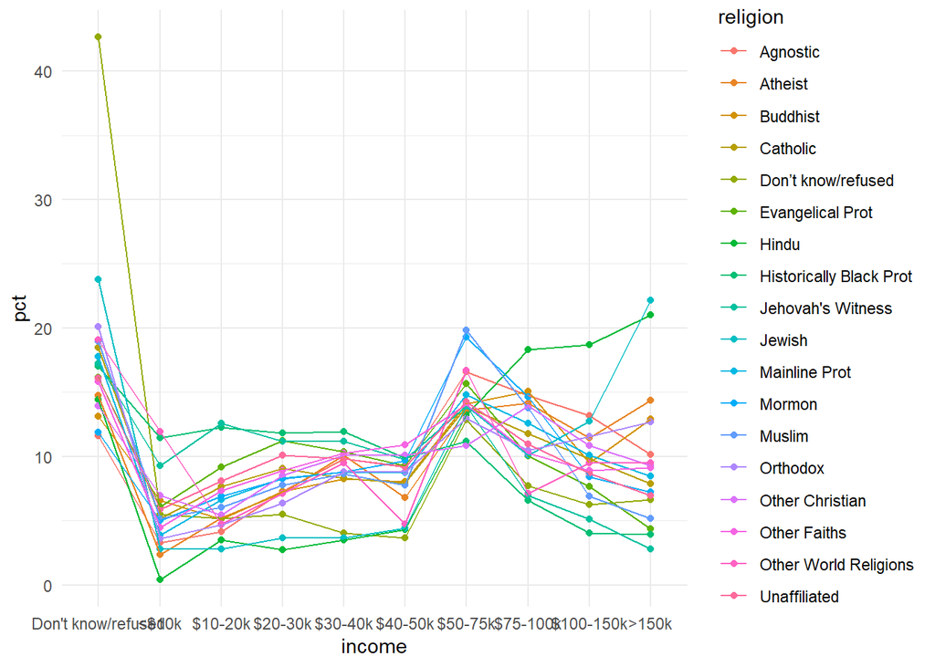

```r
relig_long %>%
  group_by(religion) %>%
  mutate(pct = frequency/sum(frequency) * 100) %>%
  ggplot(aes(income, pct, color = religion)) +
  geom_point() +
  geom_line(aes(group = religion))
```

## Why are tidy data useful?

**Or** we can facet by religion and maybe see the data better

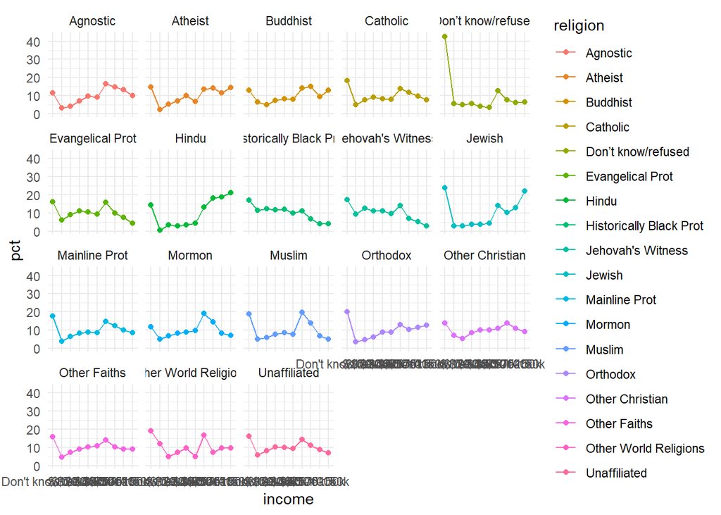

```r
relig_long %>%
  group_by(religion) %>%
  mutate(pct = frequency/sum(frequency) * 100) %>%
  ggplot(aes(income, pct, color = religion)) +
  geom_point() +
  geom_line(group = 1) +
  facet_wrap(~religion)
```

## Messy data #2

What makes this data messy?

```
# A tibble: 7,240 × 60
   country     iso2  iso3   year new_sp_m_014 new_sp_m_1524 new_sp_m_2534
   <chr>       <chr> <chr> <dbl>        <dbl>         <dbl>         <dbl>
 1 Afghanistan AF    AFG    1980           NA            NA            NA
 2 Afghanistan AF    AFG    1981           NA            NA            NA
 3 Afghanistan AF    AFG    1982           NA            NA            NA
 4 Afghanistan AF    AFG    1983           NA            NA            NA
 5 Afghanistan AF    AFG    1984           NA            NA            NA
 6 Afghanistan AF    AFG    1985           NA            NA            NA
 7 Afghanistan AF    AFG    1986           NA            NA            NA
 8 Afghanistan AF    AFG    1987           NA            NA            NA
 9 Afghanistan AF    AFG    1988           NA            NA            NA
10 Afghanistan AF    AFG    1989           NA            NA            NA
# ℹ 7,230 more rows
# ℹ 53 more variables: new_sp_m_3544 <dbl>, new_sp_m_4554 <dbl>,
#   new_sp_m_5564 <dbl>, new_sp_m_65 <dbl>, new_sp_f_014 <dbl>,
#   new_sp_f_1524 <dbl>, new_sp_f_2534 <dbl>, new_sp_f_3544 <dbl>,
#   new_sp_f_4554 <dbl>, new_sp_f_5564 <dbl>, new_sp_f_65 <dbl>,
#   new_sn_m_014 <dbl>, new_sn_m_1524 <dbl>, new_sn_m_2534 <dbl>,
#   new_sn_m_3544 <dbl>, new_sn_m_4554 <dbl>, new_sn_m_5564 <dbl>, …
```

## Messy data

Many variables in column names

```
# A tibble: 7,240 × 60
   country     iso2  iso3   year new_sp_m_014 new_sp_m_1524 new_sp_m_2534
   <chr>       <chr> <chr> <dbl>        <dbl>         <dbl>         <dbl>
 1 Afghanistan AF    AFG    1980           NA            NA            NA
 2 Afghanistan AF    AFG    1981           NA            NA            NA
 3 Afghanistan AF    AFG    1982           NA            NA            NA
 4 Afghanistan AF    AFG    1983           NA            NA            NA
 5 Afghanistan AF    AFG    1984           NA            NA            NA
 6 Afghanistan AF    AFG    1985           NA            NA            NA
 7 Afghanistan AF    AFG    1986           NA            NA            NA
 8 Afghanistan AF    AFG    1987           NA            NA            NA
 9 Afghanistan AF    AFG    1988           NA            NA            NA
10 Afghanistan AF    AFG    1989           NA            NA            NA
# ℹ 7,230 more rows
# ℹ 53 more variables: new_sp_m_3544 <dbl>, new_sp_m_4554 <dbl>,
#   new_sp_m_5564 <dbl>, new_sp_m_65 <dbl>, new_sp_f_014 <dbl>,
#   new_sp_f_1524 <dbl>, new_sp_f_2534 <dbl>, new_sp_f_3544 <dbl>,
#   new_sp_f_4554 <dbl>, new_sp_f_5564 <dbl>, new_sp_f_65 <dbl>,
#   new_sn_m_014 <dbl>, new_sn_m_1524 <dbl>, new_sn_m_2534 <dbl>,
#   new_sn_m_3544 <dbl>, new_sn_m_4554 <dbl>, new_sn_m_5564 <dbl>, …
```

## Messy data

Many variables in column names

Example column names

new_sp_m_014

new_rel_f_65

all `col` names start with new_, which we don’t need

followed by a diagnosis category: “sp_” “sn_” “ep_” “rel_”

then gender, which in these data are limited to “m_” or “f_”

and last an age range

and these are separated by underscores `_` which is quite convenient, as we’ll see

. . .

That’s a lot of information in the column names!

## Messy data

Many variables in column names

Necessary arguments

- `data` - of course
- `cols` – which columns you will pivot longer
- `names_to` – new variable name**s** (in quotes) for those `cols`
- `values_to` – new variable name (in quotes) for the cell values

. . .

## Let’s apply it

```r
who_r %>%
 pivot_longer(
  cols = new_sp_m_014:new_rel_f_65,
  names_to = c("new", "diagnosis", "sex", "age"),
  names_sep = "_",
  values_to = "count"
)
```

```
# A tibble: 405,440 × 9
   country     iso2  iso3   year new   diagnosis sex   age   count
   <chr>       <chr> <chr> <dbl> <chr> <chr>     <chr> <chr> <dbl>
 1 Afghanistan AF    AFG    1980 new   sp        m     014      NA
 2 Afghanistan AF    AFG    1980 new   sp        m     1524     NA
 3 Afghanistan AF    AFG    1980 new   sp        m     2534     NA
 4 Afghanistan AF    AFG    1980 new   sp        m     3544     NA
 5 Afghanistan AF    AFG    1980 new   sp        m     4554     NA
 6 Afghanistan AF    AFG    1980 new   sp        m     5564     NA
 7 Afghanistan AF    AFG    1980 new   sp        m     65       NA
 8 Afghanistan AF    AFG    1980 new   sp        f     014      NA
 9 Afghanistan AF    AFG    1980 new   sp        f     1524     NA
10 Afghanistan AF    AFG    1980 new   sp        f     2534     NA
# ℹ 405,430 more rows
```

## Let’s apply it

Even better, use `names_prefix` and remove the `new` column

```r
who_r %>%
 pivot_longer(
  cols = new_sp_m_014:new_rel_f_65,
  names_to = c("diagnosis", "sex", "age"),
  names_prefix = "new_",
  names_sep = "_",
  values_to = "count"
)
```

```
# A tibble: 405,440 × 8
   country     iso2  iso3   year diagnosis sex   age   count
   <chr>       <chr> <chr> <dbl> <chr>     <chr> <chr> <dbl>
 1 Afghanistan AF    AFG    1980 sp        m     014      NA
 2 Afghanistan AF    AFG    1980 sp        m     1524     NA
 3 Afghanistan AF    AFG    1980 sp        m     2534     NA
 4 Afghanistan AF    AFG    1980 sp        m     3544     NA
 5 Afghanistan AF    AFG    1980 sp        m     4554     NA
 6 Afghanistan AF    AFG    1980 sp        m     5564     NA
 7 Afghanistan AF    AFG    1980 sp        m     65       NA
 8 Afghanistan AF    AFG    1980 sp        f     014      NA
 9 Afghanistan AF    AFG    1980 sp        f     1524     NA
10 Afghanistan AF    AFG    1980 sp        f     2534     NA
# ℹ 405,430 more rows
```

## Don’t get discouraged!

It’s hard to understand tidy principles unless you spend a lot of time working with data

Data is often organised to make **data entry** as easy as possible

- Tidying is tricky!
- Takes practice!
- Takes trial and error!
- Takes looking at the [help documentation](https://tidyr.tidyverse.org/reference/pivot_longer.html) and the [vignette](https://tidyr.tidyverse.org/articles/pivot.html) - a lot
- Takes learning and re-learning - a lot!
- Takes trial and error!
- But you are rarely never gifted with tidy data!

## Declaring `cols` to `pivot_longer`

We can declare the columns to pivot other ways

The important part is just being clear which columns should be part of the gather

All of the below are equivalent

`relig_income` data

```r
relig_income %>%
  pivot_longer(
    cols = -religion,
    ...
```

```r
relig_income %>%
  pivot_longer(
    cols = -1,
    ...
```

```r
names(relig_income) %>%
  pivot_longer(
    cols = c(`<$10k`:`Don't know/refused`),
    ...
```

`who` data

```r
names(who) %>%
  pivot_longer(
    cols = new_sp_m_014:new_rel_f_65,
    ...
```

```r
names(who) %>%
  pivot_longer(
    cols = starts_with("new_"),
    ...
```

## Let’s look at some education data

Load the `exam1.csv` data from the course website or from your cloned course repo

- Did you clone the course repo?

Start a new `R` script or qmd

```r
library(tidyverse)
library(here)
exam <- read_csv(here("data", "exam1.csv"))
```

## exam1 data

```
# A tibble: 35 × 20
   stu_name gender item_1 item_2 item_3 item_4 item_5 item_6 item_7 item_8
   <chr>    <chr>   <dbl>  <dbl>  <dbl>  <dbl>  <dbl>  <dbl>  <dbl>  <dbl>
 1 Adam     M           1      1      1      1      1      1      1      0
 2 Anne     F           1      1      1      1      1      1      1      1
 3 Audrey   F           1      1      1      1      1      1      1      1
 4 Barbara  F           1      1      1      1      0      0      1      0
 5 Bert     M           1      1      1      1      1      0      1      0
 6 Betty    F           1      1      1      1      1      1      1      1
 7 Blaise   M           1      1      1      1      1      1      1      1
 8 Brenda   F           1      1      1      1      1      1      1      1
 9 Britton  F           1      1      1      0      1      1      1      1
10 Carol    F           1      1      1      1      0      0      1      0
# ℹ 25 more rows
# ℹ 10 more variables: item_9 <dbl>, item_10 <dbl>, item_11 <dbl>,
#   item_12 <dbl>, item_13 <dbl>, item_14 <dbl>, item_15 <dbl>, item_16 <dbl>,
#   item_17 <dbl>, item_18 <dbl>
```

## Talk with a neighbor

- Are these data tidy?
- If not, what needs to happen to make them tidy?
- What are the variables? What are the values?

`03:00`

## exam1 data

What do we want?

. . .

Let’s change all `item` variables into two variables: `item` and `score`

. . .

```
# A tibble: 630 × 4
   stu_name gender item    score
   <chr>    <chr>  <chr>   <dbl>
 1 Adam     M      item_1      1
 2 Adam     M      item_2      1
 3 Adam     M      item_3      1
 4 Adam     M      item_4      1
 5 Adam     M      item_5      1
 6 Adam     M      item_6      1
 7 Adam     M      item_7      1
 8 Adam     M      item_8      0
 9 Adam     M      item_9      0
10 Adam     M      item_10     0
# ℹ 620 more rows
```

## Try to tidy!

Necessary arguments

- `data` - of course
- `cols` – which columns you will pivot longer
- `names_to` – new variable name (in quotes) for those `cols`
  - *“item”*
- `values_to` – new variable name (in quotes) for the cell values
  - *“score”*

`05:00`

**Don’t look ahead!**

## exam1 tidy

```r
exam %>%
  pivot_longer(
    cols = starts_with("item"),
    names_to = "item",
    values_to = "score"
  )
```

```
# A tibble: 630 × 4
   stu_name gender item    score
   <chr>    <chr>  <chr>   <dbl>
 1 Adam     M      item_1      1
 2 Adam     M      item_2      1
 3 Adam     M      item_3      1
 4 Adam     M      item_4      1
 5 Adam     M      item_5      1
 6 Adam     M      item_6      1
 7 Adam     M      item_7      1
 8 Adam     M      item_8      0
 9 Adam     M      item_9      0
10 Adam     M      item_10     0
# ℹ 620 more rows
```

## exam1 tidy

Let’s go one step further

```r
exam %>%
  pivot_longer(
    cols = starts_with("item"),
    names_to = "item",
    names_prefix = "item_",
    values_to = "score"
  )
```

```
# A tibble: 630 × 4
   stu_name gender item  score
   <chr>    <chr>  <chr> <dbl>
 1 Adam     M      1         1
 2 Adam     M      2         1
 3 Adam     M      3         1
 4 Adam     M      4         1
 5 Adam     M      5         1
 6 Adam     M      6         1
 7 Adam     M      7         1
 8 Adam     M      8         0
 9 Adam     M      9         0
10 Adam     M      10        0
# ℹ 620 more rows
```

## exam1 tidy

And another step

```r
(exam_tidy <- exam %>%
  pivot_longer(
    cols = starts_with("item"),
    names_to = "item",
    names_prefix = "item_",
    names_transform = list(item = as.integer),
    values_to = "score"
  ))
```

```
# A tibble: 630 × 4
   stu_name gender  item score
   <chr>    <chr>  <int> <dbl>
 1 Adam     M          1     1
 2 Adam     M          2     1
 3 Adam     M          3     1
 4 Adam     M          4     1
 5 Adam     M          5     1
 6 Adam     M          6     1
 7 Adam     M          7     1
 8 Adam     M          8     0
 9 Adam     M          9     0
10 Adam     M         10     0
# ℹ 620 more rows
```

. . .

Why not quotes around *item* here, but quotes as it appears in `names_to`?

## One more look at `names_prefix =`

```r
who_r %>%
 pivot_longer(
  cols = new_sp_m_014:new_rel_f_65,
  names_to = c("new", "diagnosis", "sex", "age"),
  names_sep = "_",
  values_to = "count"
)
```

```
# A tibble: 405,440 × 9
   country     iso2  iso3   year new   diagnosis sex   age   count
   <chr>       <chr> <chr> <dbl> <chr> <chr>     <chr> <chr> <dbl>
 1 Afghanistan AF    AFG    1980 new   sp        m     014      NA
 2 Afghanistan AF    AFG    1980 new   sp        m     1524     NA
 3 Afghanistan AF    AFG    1980 new   sp        m     2534     NA
 4 Afghanistan AF    AFG    1980 new   sp        m     3544     NA
 5 Afghanistan AF    AFG    1980 new   sp        m     4554     NA
 6 Afghanistan AF    AFG    1980 new   sp        m     5564     NA
 7 Afghanistan AF    AFG    1980 new   sp        m     65       NA
 8 Afghanistan AF    AFG    1980 new   sp        f     014      NA
 9 Afghanistan AF    AFG    1980 new   sp        f     1524     NA
10 Afghanistan AF    AFG    1980 new   sp        f     2534     NA
# ℹ 405,430 more rows
```

## One more look at `names_prefix`

```r
who_r %>%
 pivot_longer(
  cols = new_sp_m_014:new_rel_f_65,
  names_to = c("diagnosis", "sex", "age"),
  names_prefix = "new_",
  names_sep = "_",
  values_to = "count"
)
```

```
# A tibble: 405,440 × 8
   country     iso2  iso3   year diagnosis sex   age   count
   <chr>       <chr> <chr> <dbl> <chr>     <chr> <chr> <dbl>
 1 Afghanistan AF    AFG    1980 sp        m     014      NA
 2 Afghanistan AF    AFG    1980 sp        m     1524     NA
 3 Afghanistan AF    AFG    1980 sp        m     2534     NA
 4 Afghanistan AF    AFG    1980 sp        m     3544     NA
 5 Afghanistan AF    AFG    1980 sp        m     4554     NA
 6 Afghanistan AF    AFG    1980 sp        m     5564     NA
 7 Afghanistan AF    AFG    1980 sp        m     65       NA
 8 Afghanistan AF    AFG    1980 sp        f     014      NA
 9 Afghanistan AF    AFG    1980 sp        f     1524     NA
10 Afghanistan AF    AFG    1980 sp        f     2534     NA
# ℹ 405,430 more rows
```

## Why are tidy data useful?

**Question**: How would we calculate the `prop`ortion of students responding correctly to each item?

## Why are tidy data useful?

**Question**: How would we calculate the `prop`ortion of students responding correctly to each item?

**Answer**: We `group_by(item)` and `summarize()`

```r
exam_tidy %>%
  group_by(item) %>%
  summarize(prop = mean(score))
```

```
# A tibble: 18 × 2
    item   prop
   <int>  <dbl>
 1     1 1
 2     2 1
 3     3 1
 4     4 0.914
 5     5 0.886
 6     6 0.857
 7     7 0.886
 8     8 0.771
 9     9 0.857
10    10 0.686
11    11 0.343
12    12 0.171
13    13 0.2
14    14 0.0857
15    15 0.0286
16    16 0.0286
17    17 0.0286
18    18 0
```

## Why are tidy data useful?

**Question**: What if we wanted to know the `prop`ortion correct for each item by gender?

## Why are tidy data useful?

**Question**: What if we wanted to know the `prop`ortion correct for each item by gender?

**Answer**: We `group_by(item, gender)` and `summarize()`

```r
exam_tidy %>%
  group_by(item, gender) %>%
  summarize(prop = mean(score))
```

```
# A tibble: 36 × 3
# Groups:   item [18]
    item gender  prop
   <int> <chr>  <dbl>
 1     1 F      1
 2     1 M      1
 3     2 F      1
 4     2 M      1
 5     3 F      1
 6     3 M      1
 7     4 F      0.889
 8     4 M      0.941
 9     5 F      0.833
10     5 M      0.941
# ℹ 26 more rows
```

## Why are tidy data useful?

**Question**: What if we want to calculate the `total` and `percent` correct for each student?

## Why are tidy data useful?

**Question**: What if we want to calculate the `total` and `percent` correct for each student?

**Answer**: We `group_by(stu_name)` and `summarize()`

```r
exam_tidy %>%
  group_by(stu_name) %>%
  summarize(
    score_total = sum(score),
    score_pct = round(score_total/n()*100)
  )
```

```
# A tibble: 35 × 3
   stu_name score_total score_pct
   <chr>          <dbl>     <dbl>
 1 Adam               7        39
 2 Anne              10        56
 3 Audrey            11        61
 4 Barbara            6        33
 5 Bert               8        44
 6 Betty              9        50
 7 Blaise            13        72
 8 Brenda            10        56
 9 Britton            8        44
10 Carol              6        33
# ℹ 25 more rows
```

## More data

Load the `year-end_scores.csv` data from the course website or from your cloned course repo

Name the data `scores`

```r
(scores <- read_csv(here("data", "year-end_scores.csv")))
```

```
# A tibble: 10 × 7
      id   sex ethnicity  sped frl    math  read
   <dbl> <dbl>     <dbl> <dbl> <lgl> <dbl> <dbl>
 1     1     0         5     0 NA      101    99
 2     2     1         2     0 NA       96    NA
 3     3     1         5     0 NA      131   119
 4     4     1         4     0 NA       84    93
 5     5     0         1     0 NA      110   118
 6     6     0         5     1 NA       NA   105
 7     7     1         5     1 NA       93    99
 8     8     0         3     0 NA       81    77
 9     9     1         2     0 NA      129   135
10    10     0         1     0 NA      117   122
```

## Talk as a class

- Are these data tidy?
  - If you wanted to summarize both scores, or plot and use facet by `content`, what would you use to `group_by()` or `facet_wrap()`?
- What do we need to do to make these tidy?
  - What `pivot_longer()` arguments do we need?

```
# A tibble: 10 × 7
      id   sex ethnicity  sped frl    math  read
   <dbl> <dbl>     <dbl> <dbl> <lgl> <dbl> <dbl>
 1     1     0         5     0 NA      101    99
 2     2     1         2     0 NA       96    NA
 3     3     1         5     0 NA      131   119
 4     4     1         4     0 NA       84    93
 5     5     0         1     0 NA      110   118
 6     6     0         5     1 NA       NA   105
 7     7     1         5     1 NA       93    99
 8     8     0         3     0 NA       81    77
 9     9     1         2     0 NA      129   135
10    10     0         1     0 NA      117   122
```

## Work as a class

Tidy `scores`, name new data `scores_tidy`

`03:00`

## Let’s try another

Load the `longitudinal_sim.csv` data from course website or your cloned course repo

Name the data `sim`

```r
sim <- read_csv(here("data", "longitudinal_sim.csv"))
```

## Talk with a neighbor

- Are these data tidy?
  - If you wanted to summarize scores, or plot and use facet, what would you use to `group_by()` or `facet_wrap()`?
- What do we need to do to make these tidy?
  - What `pivot_longer()` arguments do we need?

. . .

Work with your neighbor to tidy, name new data `tidy_sim`

`05:00`

Tell me your solutions

demo a couple

## Other possible issues

The `hiv` data

```r
(hiv <- read_csv(here("data", "hiv.csv")))
```

```
# A tibble: 275 × 34
   country        `1979` `1980` `1981` `1982` `1983` `1984` `1985` `1986` `1987`
   <chr>           <dbl>  <dbl>  <dbl>  <dbl>  <dbl>  <dbl>  <dbl>  <dbl>  <dbl>
 1 Abkhazia      NA          NA     NA     NA     NA     NA     NA     NA     NA
 2 Afghanistan   NA          NA     NA     NA     NA     NA     NA     NA     NA
 3 Akrotiri and… NA          NA     NA     NA     NA     NA     NA     NA     NA
 4 Albania       NA          NA     NA     NA     NA     NA     NA     NA     NA
 5 Algeria       NA          NA     NA     NA     NA     NA     NA     NA     NA
 6 American Sam… NA          NA     NA     NA     NA     NA     NA     NA     NA
 7 Andorra       NA          NA     NA     NA     NA     NA     NA     NA     NA
 8 Angola         0.0265     NA     NA     NA     NA     NA     NA     NA     NA
 9 Anguilla      NA          NA     NA     NA     NA     NA     NA     NA     NA
10 Antigua and … NA          NA     NA     NA     NA     NA     NA     NA     NA
# ℹ 265 more rows
# ℹ 24 more variables: `1988` <lgl>, `1989` <lgl>, `1990` <dbl>, `1991` <dbl>,
#   `1992` <dbl>, `1993` <dbl>, `1994` <dbl>, `1995` <dbl>, `1996` <dbl>,
#   `1997` <dbl>, `1998` <dbl>, `1999` <dbl>, `2000` <dbl>, `2001` <dbl>,
#   `2002` <dbl>, `2003` <dbl>, `2004` <dbl>, `2005` <dbl>, `2006` <dbl>,
#   `2007` <dbl>, `2008` <dbl>, `2009` <dbl>, `2010` <dbl>, `2011` <dbl>
```

## Other possible issues

Let’s make some manipulations to get a sample of the data

- just `{dplyr}` variety `filter()` and `select()`

```r
(hiv_r <- hiv %>%
  filter(country == "France" |
          country == "South Africa" |
            country == "United States") %>%
  select(country, `1979`, `1989`, `1999`, `2009`))
```

```
# A tibble: 3 × 5
  country        `1979` `1989` `1999` `2009`
  <chr>           <dbl> <lgl>   <dbl>  <dbl>
1 France        NA      NA        0.3    0.4
2 South Africa  NA      NA       14.8   17.2
3 United States  0.0318 NA        0.5    0.6
```

. . .

- Are these data tidy?
- Discuss how you would transform these data, if at all

## Tidy the data

```r
(hiv_tidy <- hiv_r %>%
  pivot_longer(
    cols = -1,
    names_to = "year",
    values_to = "percentage"
  )
)
```

```
# A tibble: 12 × 3
   country       year  percentage
   <chr>         <chr>      <dbl>
 1 France        1979     NA
 2 France        1989     NA
 3 France        1999      0.3
 4 France        2009      0.4
 5 South Africa  1979     NA
 6 South Africa  1989     NA
 7 South Africa  1999     14.8
 8 South Africa  2009     17.2
 9 United States 1979      0.0318
10 United States 1989     NA
11 United States 1999      0.5
12 United States 2009      0.6
```

## Let’s plot it

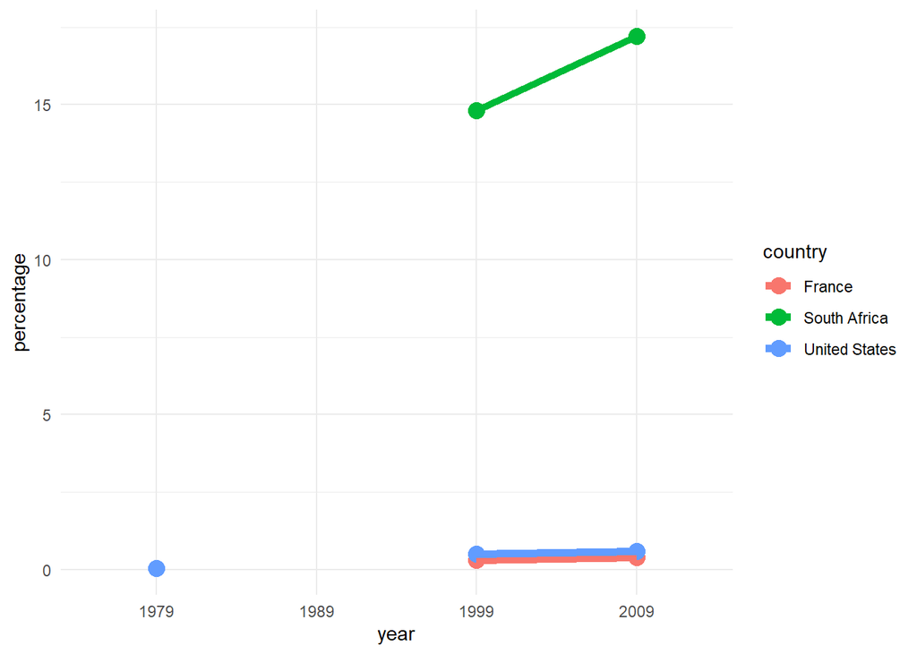

```r
hiv_tidy %>%
  ggplot(aes(year, percentage, color = country, group = country)) +
  geom_point(size = 4) +
  geom_line(size = 2)
```

## Let’s plot it

There is a problem with the data – what is it?

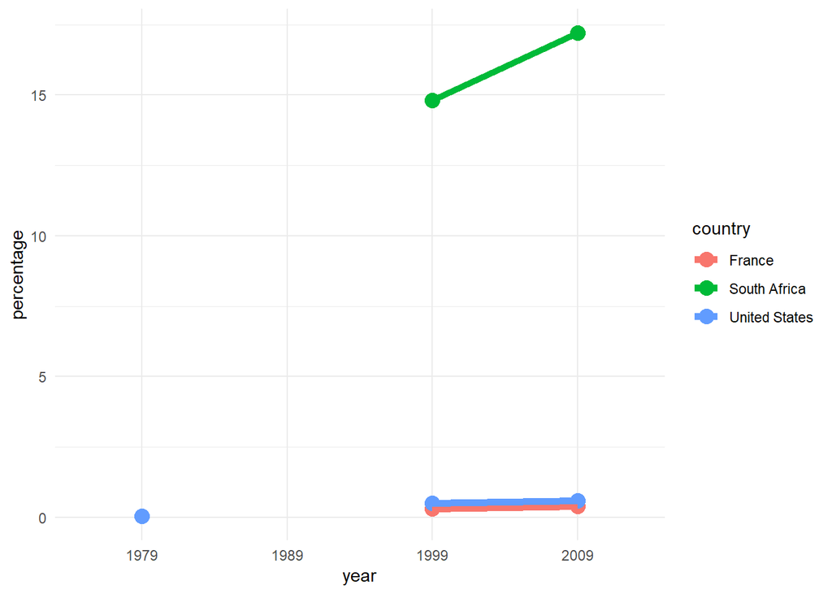

. . .

Why aren’t lines connecting for the United States?

## Missing data

```r
hiv_tidy
```

```
# A tibble: 12 × 3
   country       year  percentage
   <chr>         <chr>      <dbl>
 1 France        1979     NA
 2 France        1989     NA
 3 France        1999      0.3
 4 France        2009      0.4
 5 South Africa  1979     NA
 6 South Africa  1989     NA
 7 South Africa  1999     14.8
 8 South Africa  2009     17.2
 9 United States 1979      0.0318
10 United States 1989     NA
11 United States 1999      0.5
12 United States 2009      0.6
```

## Drop `NA`s

```r
hiv_tidy %>%
  drop_na(percentage)
```

**OR**

(if you’re **certain** you can remove these missing data)

```r
hiv_tidy <- hiv_r %>%
  pivot_longer(
    cols = -1,
    names_to = "year",
    values_to = "percentage",
    names_transform = list(year = as.integer),
    values_drop_na = TRUE
  )
```

## Plot again

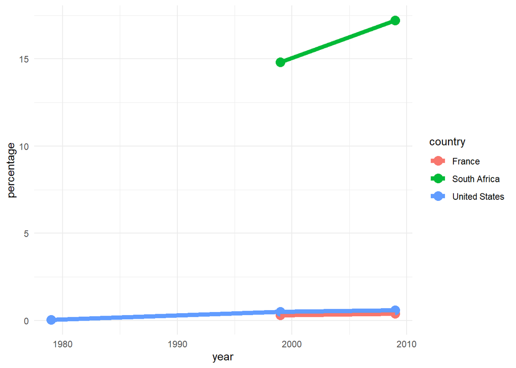

```r
hiv_tidy %>%
  ggplot(aes(year, percentage, color = country, group = country)) +
  geom_point(size = 4) +
  geom_line(size = 2)
```

# `pivot_wider()`

## [`pivot_wider()`](https://tidyr.tidyverse.org/reference/pivot_wider.html)

- Tidy data are excellent when conducting preliminary descriptive analyses, plotting data, linear models
- Occasionally, you need the data in a different format
- if you’re using other packages or software for analysis
  - specific modeling purposes (SEM)
  - or you have two outcomes variables that might need to be separate column
    - `math` & `rdg`

. . .

```
# A tibble: 40 × 4
     sid wave  content score
   <dbl> <chr> <chr>   <dbl>
 1     1 1     math       95
 2     1 2     math       98
 3     1 3     math      102
 4     1 4     math      105
 5     1 1     rdg        96
 6     1 2     rdg        98
 7     1 3     rdg       101
 8     1 4     rdg       103
 9     2 1     math      101
10     2 2     math      103
# ℹ 30 more rows
```

## `pivot_wider()`

```r
pivot_wider(
  data,
  ...,
  id_cols = NULL,
  names_from = name,
  names_prefix = "",
  names_sep = "_",
  names_glue = NULL,
  names_sort = FALSE,
  names_vary = "fastest",
  names_expand = FALSE
  names_repair = "check_unique",
  values_from = value,
  values_fill = NULL,
  values_fn = NULL,
  unused_fn = NULL
)
```

## `pivot_wider()`

```r
pivot_wider(
  data,
  ...,
  id_cols = NULL,
  names_from = name,
  names_prefix = "",
  names_sep = "_",
  names_glue = NULL,
  names_sort = FALSE,
  names_vary = "fastest",
  names_expand = FALSE
  names_repair = "check_unique",
  values_from = value,
  values_fill = NULL,
  values_fn = NULL,
  unused_fn = NULL
)
```

## `pivot_wider()`

```r
pivot_wider(
  data,
  names_from = name,
  values_from = value
)
```

## `pivot_wider()`

```r
pivot_wider(
  data,
  names_from = name,
  values_from = value
)
```

`names_from`: The names of the (tidy) column (or columns) from which to get the name of the new data columns

## `pivot_wider()`

```r
pivot_wider(
  data,
  names_from = name,
  values_from = value
)
```

`values_from`: The names of the (tidy) column (or columns) from which to get the the cell values

## An example

`tidyr::fish_encounters`: when fish swimming down a river are detected by automatic monitoring stations

```r
tidyr::fish_encounters
```

```
# A tibble: 114 × 3
   fish  station  seen
   <fct> <fct>   <int>
 1 4842  Release     1
 2 4842  I80_1       1
 3 4842  Lisbon      1
 4 4842  Rstr        1
 5 4842  Base_TD     1
 6 4842  BCE         1
 7 4842  BCW         1
 8 4842  BCE2        1
 9 4842  BCW2        1
10 4842  MAE         1
# ℹ 104 more rows
```

## An example

So tidy, so nice…let’s muck it up

```r
fish_encounters %>%
  pivot_wider(
    names_from = station,
    values_from = seen,
)
```

```
# A tibble: 19 × 12
   fish  Release I80_1 Lisbon  Rstr Base_TD   BCE   BCW  BCE2  BCW2   MAE   MAW
   <fct>   <int> <int>  <int> <int>   <int> <int> <int> <int> <int> <int> <int>
 1 4842        1     1      1     1       1     1     1     1     1     1     1
 2 4843        1     1      1     1       1     1     1     1     1     1     1
 3 4844        1     1      1     1       1     1     1     1     1     1     1
 4 4845        1     1      1     1       1    NA    NA    NA    NA    NA    NA
 5 4847        1     1      1    NA      NA    NA    NA    NA    NA    NA    NA
 6 4848        1     1      1     1      NA    NA    NA    NA    NA    NA    NA
 7 4849        1     1     NA    NA      NA    NA    NA    NA    NA    NA    NA
 8 4850        1     1     NA     1       1     1     1    NA    NA    NA    NA
 9 4851        1     1     NA    NA      NA    NA    NA    NA    NA    NA    NA
10 4854        1     1     NA    NA      NA    NA    NA    NA    NA    NA    NA
11 4855        1     1      1     1       1    NA    NA    NA    NA    NA    NA
12 4857        1     1      1     1       1     1     1     1     1    NA    NA
13 4858        1     1      1     1       1     1     1     1     1     1     1
14 4859        1     1      1     1       1    NA    NA    NA    NA    NA    NA
15 4861        1     1      1     1       1     1     1     1     1     1     1
16 4862        1     1      1     1       1     1     1     1     1    NA    NA
17 4863        1     1     NA    NA      NA    NA    NA    NA    NA    NA    NA
18 4864        1     1     NA    NA      NA    NA    NA    NA    NA    NA    NA
19 4865        1     1      1    NA      NA    NA    NA    NA    NA    NA    NA
```

## An example

That’s a lot of `NA` values. But are they really “missing”?

```r
fish_encounters %>%
  pivot_wider(
    names_from = station,
    values_from = seen,
)
```

```
# A tibble: 19 × 12
   fish  Release I80_1 Lisbon  Rstr Base_TD   BCE   BCW  BCE2  BCW2   MAE   MAW
   <fct>   <int> <int>  <int> <int>   <int> <int> <int> <int> <int> <int> <int>
 1 4842        1     1      1     1       1     1     1     1     1     1     1
 2 4843        1     1      1     1       1     1     1     1     1     1     1
 3 4844        1     1      1     1       1     1     1     1     1     1     1
 4 4845        1     1      1     1       1    NA    NA    NA    NA    NA    NA
 5 4847        1     1      1    NA      NA    NA    NA    NA    NA    NA    NA
 6 4848        1     1      1     1      NA    NA    NA    NA    NA    NA    NA
 7 4849        1     1     NA    NA      NA    NA    NA    NA    NA    NA    NA
 8 4850        1     1     NA     1       1     1     1    NA    NA    NA    NA
 9 4851        1     1     NA    NA      NA    NA    NA    NA    NA    NA    NA
10 4854        1     1     NA    NA      NA    NA    NA    NA    NA    NA    NA
11 4855        1     1      1     1       1    NA    NA    NA    NA    NA    NA
12 4857        1     1      1     1       1     1     1     1     1    NA    NA
13 4858        1     1      1     1       1     1     1     1     1     1     1
14 4859        1     1      1     1       1    NA    NA    NA    NA    NA    NA
15 4861        1     1      1     1       1     1     1     1     1     1     1
16 4862        1     1      1     1       1     1     1     1     1    NA    NA
17 4863        1     1     NA    NA      NA    NA    NA    NA    NA    NA    NA
18 4864        1     1     NA    NA      NA    NA    NA    NA    NA    NA    NA
19 4865        1     1      1    NA      NA    NA    NA    NA    NA    NA    NA
```

## An example

Maybe those `NA`s should be zeroes

```r
fish_encounters %>%
  pivot_wider(
    names_from = station,
    values_from = seen,
    values_fill = list(seen = 0)
)
```

```
# A tibble: 19 × 12
   fish  Release I80_1 Lisbon  Rstr Base_TD   BCE   BCW  BCE2  BCW2   MAE   MAW
   <fct>   <int> <int>  <int> <int>   <int> <int> <int> <int> <int> <int> <int>
 1 4842        1     1      1     1       1     1     1     1     1     1     1
 2 4843        1     1      1     1       1     1     1     1     1     1     1
 3 4844        1     1      1     1       1     1     1     1     1     1     1
 4 4845        1     1      1     1       1     0     0     0     0     0     0
 5 4847        1     1      1     0       0     0     0     0     0     0     0
 6 4848        1     1      1     1       0     0     0     0     0     0     0
 7 4849        1     1      0     0       0     0     0     0     0     0     0
 8 4850        1     1      0     1       1     1     1     0     0     0     0
 9 4851        1     1      0     0       0     0     0     0     0     0     0
10 4854        1     1      0     0       0     0     0     0     0     0     0
11 4855        1     1      1     1       1     0     0     0     0     0     0
12 4857        1     1      1     1       1     1     1     1     1     0     0
13 4858        1     1      1     1       1     1     1     1     1     1     1
14 4859        1     1      1     1       1     0     0     0     0     0     0
15 4861        1     1      1     1       1     1     1     1     1     1     1
16 4862        1     1      1     1       1     1     1     1     1     0     0
17 4863        1     1      0     0       0     0     0     0     0     0     0
18 4864        1     1      0     0       0     0     0     0     0     0     0
19 4865        1     1      1     0       0     0     0     0     0     0     0
```

## Remember `scores_tidy`?

```r
scores_tidy
```

```
# A tibble: 20 × 7
      id   sex ethnicity  sped frl   content score
   <dbl> <dbl>     <dbl> <dbl> <lgl> <chr>   <dbl>
 1     1     0         5     0 NA    math      101
 2     1     0         5     0 NA    read       99
 3     2     1         2     0 NA    math       96
 4     2     1         2     0 NA    read       NA
 5     3     1         5     0 NA    math      131
 6     3     1         5     0 NA    read      119
 7     4     1         4     0 NA    math       84
 8     4     1         4     0 NA    read       93
 9     5     0         1     0 NA    math      110
10     5     0         1     0 NA    read      118
11     6     0         5     1 NA    math       NA
12     6     0         5     1 NA    read      105
13     7     1         5     1 NA    math       93
14     7     1         5     1 NA    read       99
15     8     0         3     0 NA    math       81
16     8     0         3     0 NA    read       77
17     9     1         2     0 NA    math      129
18     9     1         2     0 NA    read      135
19    10     0         1     0 NA    math      117
20    10     0         1     0 NA    read      122
```

## Untidy `scores_tidy`

```r
scores_tidy %>%
  pivot_wider(
    names_from = content,
    values_from = score
  )
```

```
# A tibble: 10 × 7
      id   sex ethnicity  sped frl    math  read
   <dbl> <dbl>     <dbl> <dbl> <lgl> <dbl> <dbl>
 1     1     0         5     0 NA      101    99
 2     2     1         2     0 NA       96    NA
 3     3     1         5     0 NA      131   119
 4     4     1         4     0 NA       84    93
 5     5     0         1     0 NA      110   118
 6     6     0         5     1 NA       NA   105
 7     7     1         5     1 NA       93    99
 8     8     0         3     0 NA       81    77
 9     9     1         2     0 NA      129   135
10    10     0         1     0 NA      117   122
```

Same as the original data

```r
read_csv(here("data", "year-end_scores.csv"))
```

```
# A tibble: 10 × 7
      id   sex ethnicity  sped frl    math  read
   <dbl> <dbl>     <dbl> <dbl> <lgl> <dbl> <dbl>
 1     1     0         5     0 NA      101    99
 2     2     1         2     0 NA       96    NA
 3     3     1         5     0 NA      131   119
 4     4     1         4     0 NA       84    93
 5     5     0         1     0 NA      110   118
 6     6     0         5     1 NA       NA   105
 7     7     1         5     1 NA       93    99
 8     8     0         3     0 NA       81    77
 9     9     1         2     0 NA      129   135
10    10     0         1     0 NA      117   122
```

## Let’s do this together

Use `pivot_wider()` to change *sim_tidy* back to *sim*

```r
sim_tidy
```

```
# A tibble: 40 × 4
     sid wave  content score
   <dbl> <chr> <chr>   <dbl>
 1     1 1     math       95
 2     1 2     math       98
 3     1 3     math      102
 4     1 4     math      105
 5     1 1     rdg        96
 6     1 2     rdg        98
 7     1 3     rdg       101
 8     1 4     rdg       103
 9     2 1     math      101
10     2 2     math      103
# ℹ 30 more rows
```

```r
sim
```

```
# A tibble: 5 × 9
    sid wave_1_math wave_2_math wave_3_math wave_4_math wave_1_rdg wave_2_rdg
  <dbl>       <dbl>       <dbl>       <dbl>       <dbl>      <dbl>      <dbl>
1     1          95          98         102         105         96         98
2     2         101         103         107         109        108        110
3     3          99         103         106         110        103        106
4     4         109         111         115         116        108        109
5     5         101         104         107         113         92         95
# ℹ 2 more variables: wave_3_rdg <dbl>, wave_4_rdg <dbl>
```

## Longer then wider

Some problems can’t be solved by pivoting in a single direction

Here is an example of how you might combine `pivot_longer()` and `pivot_wider()` to solve more complex problems

. . .

```r
sim2 <- read_csv(here("data", "longitudinal_sim2.csv"))
sim2
```

```
# A tibble: 100 × 19
     SID male_g6 male_g7 male_g8 ell_g6 ell_g7 ell_g8 sped_g6 sped_g7 sped_g8
   <dbl>   <dbl>   <dbl>   <dbl>  <dbl>  <dbl>  <dbl>   <dbl>   <dbl>   <dbl>
 1     1       1       1       1      0      0      0       0       0       0
 2     2       0       0       0      0      0      0       0       0       0
 3     3       1       1       1      0      0      0       0       0       0
 4     4       1       1       1      0      0      0       0       0       0
 5     5       0       0       0      0      0      0       1       1       1
 6     6       0       0       0      0      0      0       0       0       0
 7     7       1       1       1      0      0      0       0       0       0
 8     8       1       1       1      1      1      1       0       0       0
 9     9       0       0       0      0      0      0       0       0       0
10    10       0       0       0      0      0      0       0       0       0
# ℹ 90 more rows
# ℹ 9 more variables: pullouts_g6 <dbl>, pullouts_g7 <dbl>, pullouts_g8 <dbl>,
#   disability_g6 <chr>, disability_g7 <chr>, disability_g8 <chr>,
#   score_g6 <dbl>, score_g7 <dbl>, score_g8 <dbl>
```

. . .

View() data

## First `pivot_longer()`

```r
sim2 %>%
  pivot_longer(
    cols = -1,
    names_to = c("variable", "grade"),
    values_to = "values",
    names_sep = "_")
```

```
Error in `pivot_longer()`:
! Can't combine `male_g6` <double> and `disability_g6` <character>.
```

## Combine `numeric` & `character` - `as.character`

```r
sim2 %>%
  pivot_longer(
    cols = -1,
    names_to = c("variable", "grade"),
    values_to = "values",
    names_sep = "_",
    values_transform = list(values = as.character)) # to combine numeric & character
```

```
# A tibble: 1,800 × 4
     SID variable grade values
   <dbl> <chr>    <chr> <chr>
 1     1 male     g6    1
 2     1 male     g7    1
 3     1 male     g8    1
 4     1 ell      g6    0
 5     1 ell      g7    0
 6     1 ell      g8    0
 7     1 sped     g6    0
 8     1 sped     g7    0
 9     1 sped     g8    0
10     1 pullouts g6    0
# ℹ 1,790 more rows
```

## One of my favorite functions - `parse_number()`

```r
sim2 %>%
  pivot_longer(
    cols = -1,
    names_to = c("variable", "grade"),
    values_to = "values",
    names_sep = "_",
    values_transform = list(values = as.character)) %>%
  mutate(grade = parse_number(grade))
```

```
# A tibble: 1,800 × 4
     SID variable grade values
   <dbl> <chr>    <dbl> <chr>
 1     1 male         6 1
 2     1 male         7 1
 3     1 male         8 1
 4     1 ell          6 0
 5     1 ell          7 0
 6     1 ell          8 0
 7     1 sped         6 0
 8     1 sped         7 0
 9     1 sped         8 0
10     1 pullouts     6 0
# ℹ 1,790 more rows
```

## Then `pivot_wider()`

```r
sim2 %>%
  pivot_longer(
    cols = -1,
    names_to = c("variable", "grade"),
    values_to = "values",
    names_sep = "_",
    values_transform = list(values = as.character)) %>%
  mutate(grade = parse_number(grade)) %>%
  pivot_wider(
    names_from = variable,
    values_from = values
  )
```

```
# A tibble: 300 × 8
     SID grade male  ell   sped  pullouts disability score
   <dbl> <dbl> <chr> <chr> <chr> <chr>    <chr>      <chr>
 1     1     6 1     0     0     0        none       204.711224219096
 2     1     7 1     0     0     0        none       207.641655929138
 3     1     8 1     0     0     0        none       211.468672710232
 4     2     6 0     0     0     1        none       212.343498534668
 5     2     7 0     0     0     1        none       217.565910013073
 6     2     8 0     0     0     1        none       227.036910872597
 7     3     6 1     0     0     0        none       215.436668173264
 8     3     7 1     0     0     0        none       217.029498660224
 9     3     8 1     0     0     0        none       222.232373013961
10     4     6 1     0     0     0        none       219.182457533654
# ℹ 290 more rows
```

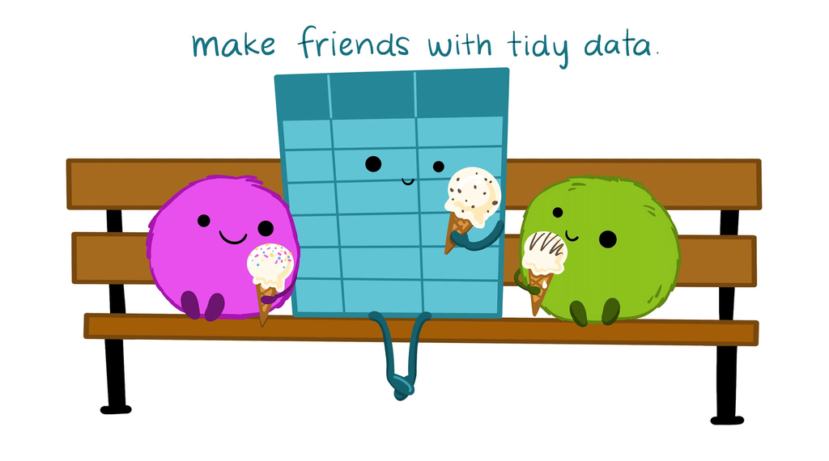

Credit [Allison Horst](https://allisonhorst.com/data-science-art)

# Next time

## Before next class

- Final Project
  - Final Project: Draft Data Script
  - Send me your repo link & document name
- Homework
  - **Homework 9**
- Reading
  - [R4DS(2e) 17](https://r4ds.hadley.nz/factors)
- AMA (Week 10)

# Homework 9